# Gender Equality Trends

Dominic Teo

## Introduction

The fight for gender equality has often found its most important battlegrounds to be in national parliaments, middle and senior management of private firms as well as in ownership groups of firms. [Studies](https://www.vox.com/2016/7/27/12266378/electing-women-congress-hillary-clinton) have shown that women members of national parliaments are more likely to introduce legislation that benefits women hence are an important part in the fight to getting rid of institutional gender inequality. On the other hand, the gender glass ceiling and gender wage gaps in private companies are not only another obstacle in the gender equality movement but is also a drag on economic growth. Research conducted at the [Booth School of Business](https://www.sciencedaily.com/releases/2018/08/180822150812.htm) have found that women continue to face resistance in joining the upper echelons of private companies.

It is clear that increasing female representation in national parliaments and in the upper echelons of private firms is an important metric of gender equality. However, it is also apparent that progress in these areas have not been even across the world. Hence, the purpose of this analysis is threefold. Firstly, this analysis will seek to identify regional trends to determine which Continents are doing well and which are faring poorly in increasing female representation in the different arenas. Secondly, this analysis will also attempt to identify any relationship between female representation in national parliaments, middle and senior management as well as ownership of firms. Finally, this analysis will try to use these three areas of female representation as predictor variables for predicting a general gender equality score hence evaluating which predictor variable appears to be more important.

## Regional Trends

### Female Share of Senior & Middle Management

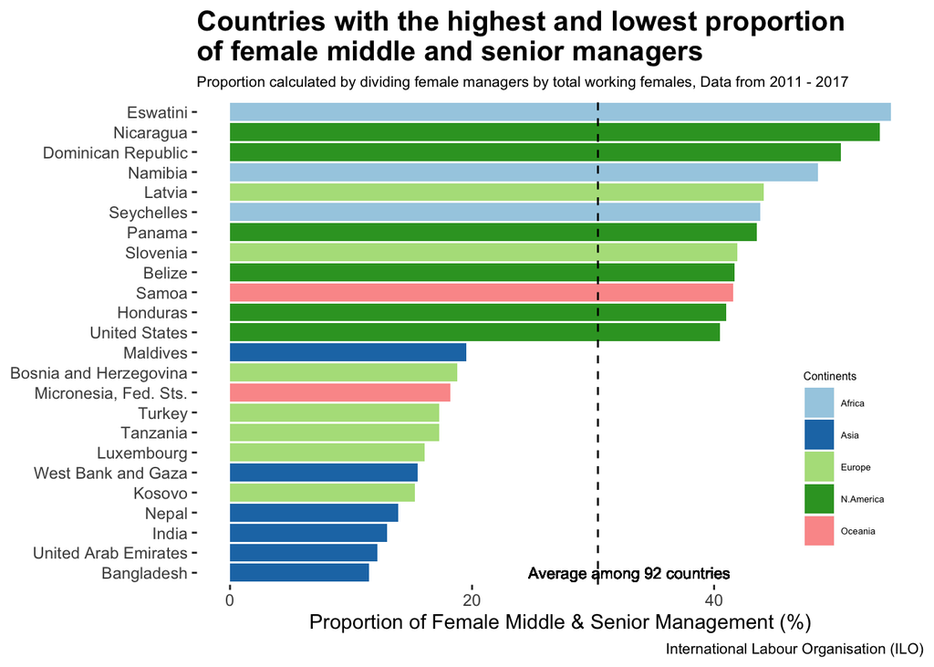

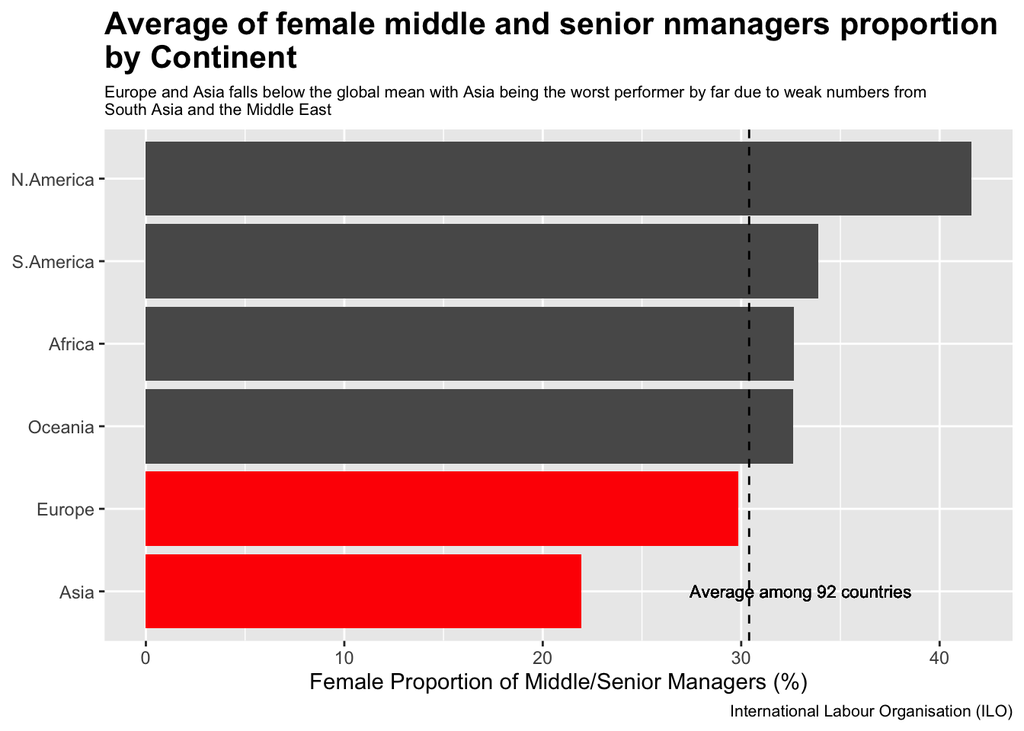

### Female Share of Firm Ownership

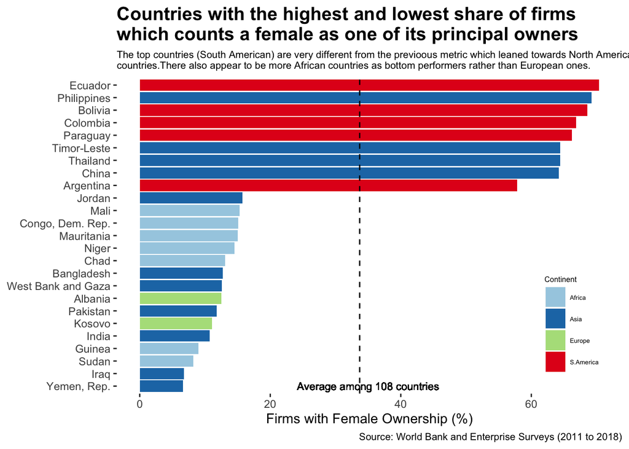

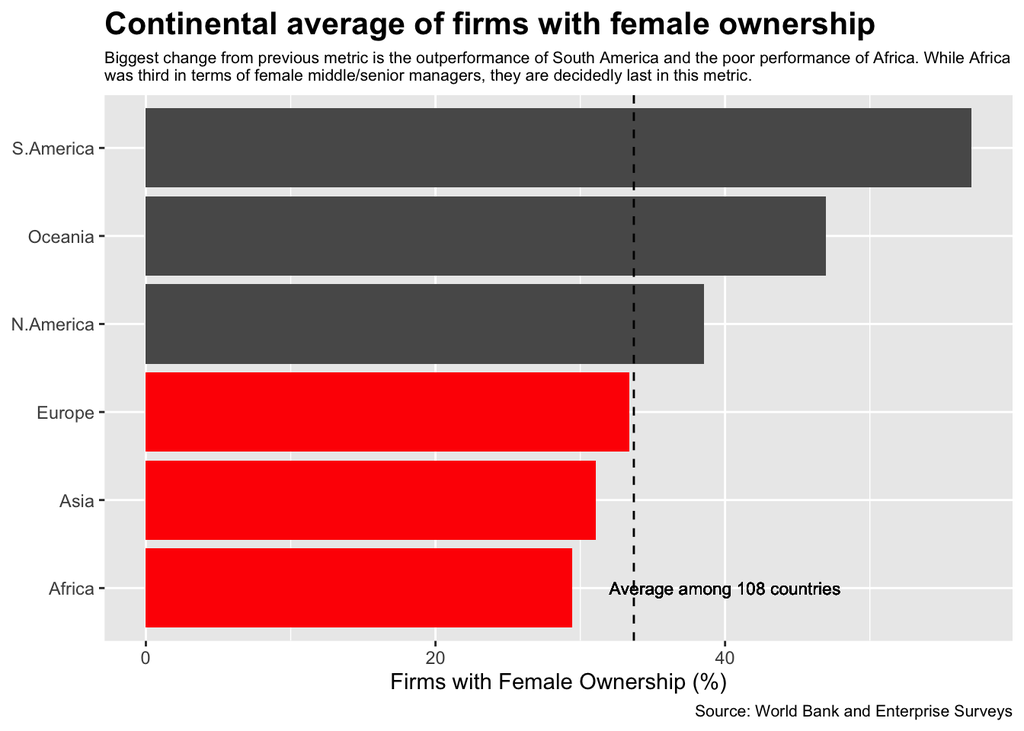

### Female Share of National Parliamentary Seats

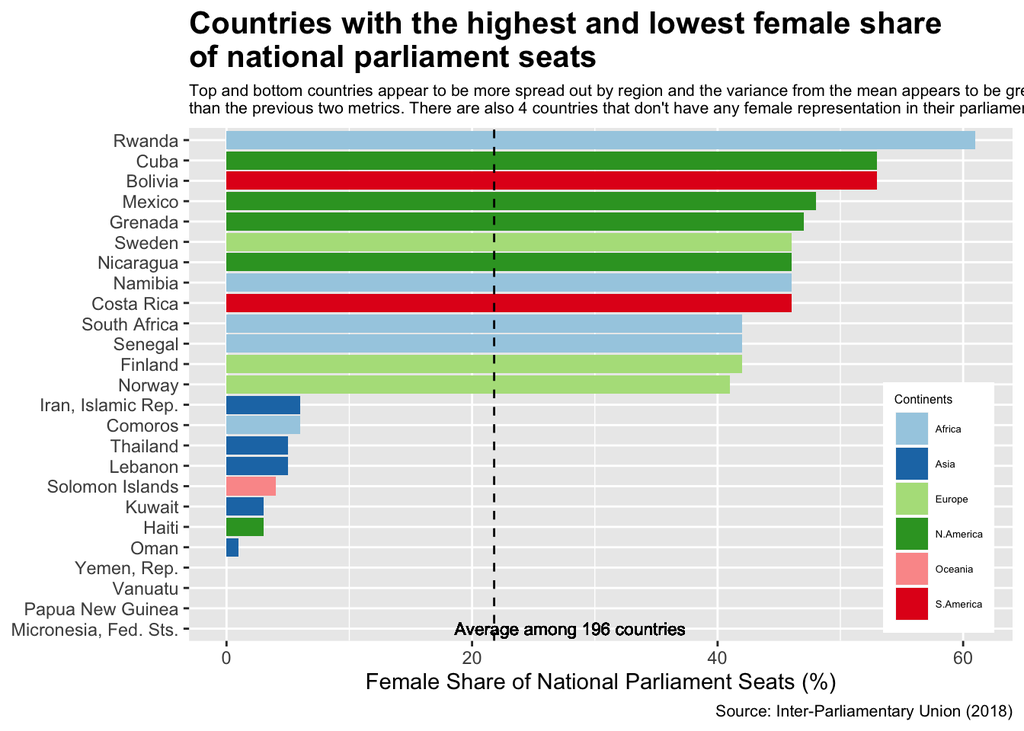

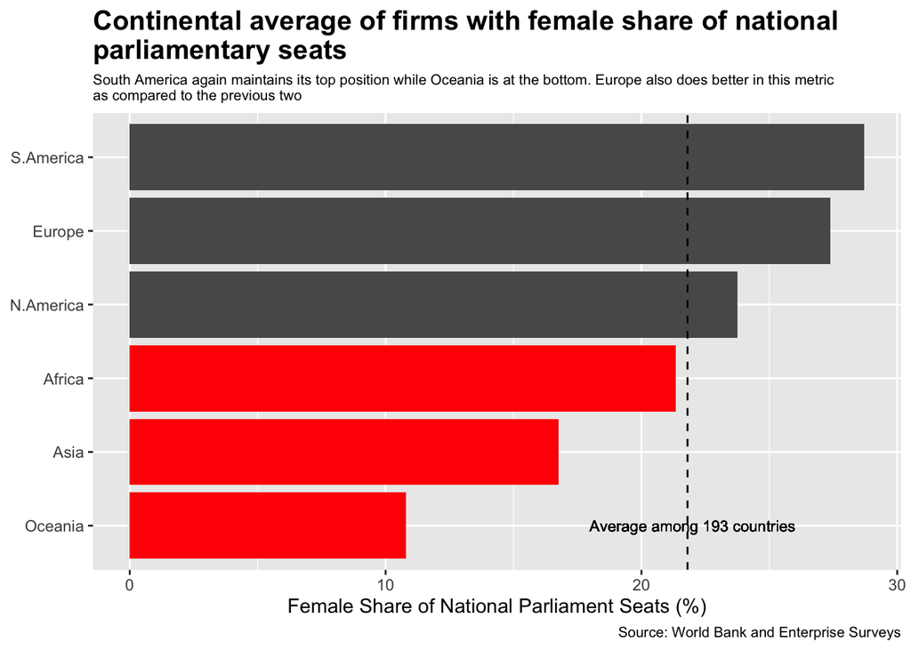

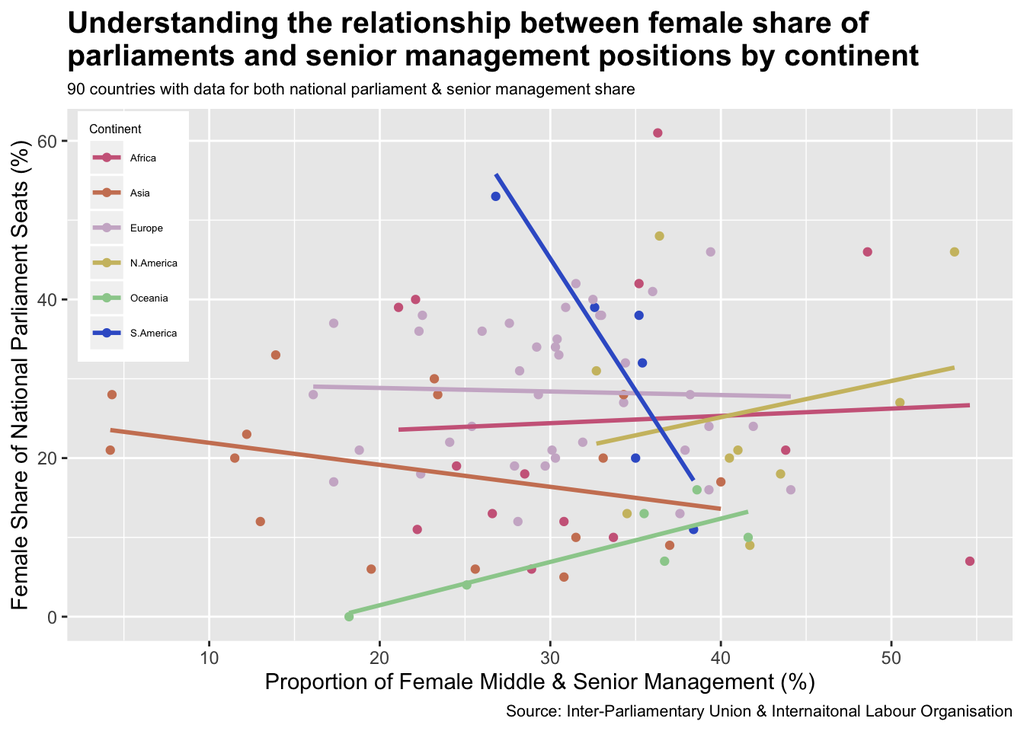

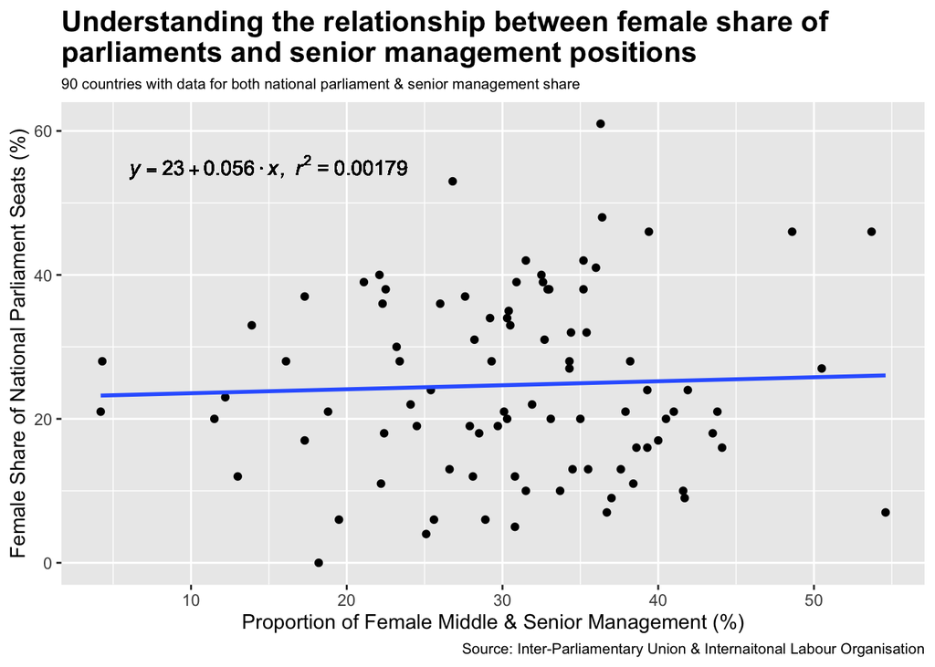

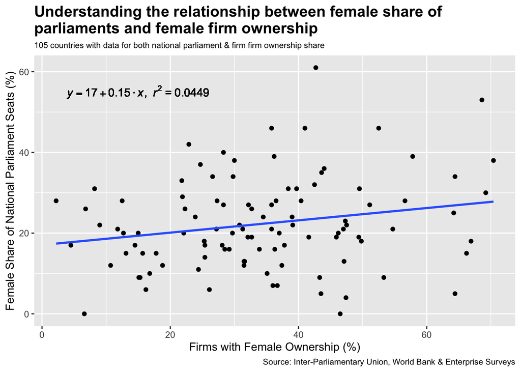